# Evaluations of positive and negative stimuli using the Affective Misattribution Procedure (AMP) and self-reports

Analysis

11 January, 2024

# Dependencies

```r
library(tidyverse)
library(knitr)
library(kableExtra)
library(janitor)
library(scales)
library(psych)
library(ggplot2)
library(easystats)
library(wesanderson)
library(patchwork)
library(cowplot)
```

# Data

Load the processed data and apply the global exclusions.

```r
data_processed <- read_csv("../data/processed/data_processed_robine.csv")
```

# Sample desciptives

## Sample size before master exclusion

```r
data_processed |>
  count(name = "n") |>
  kable() |>
  add_header_above(header = c("Whole sample" = 1)) |>
  kable_classic(full_width = FALSE)
```

| Whole sample n |
| --- |
| 179 |

## Exclude participants

Those participants who are set to “exclude” in the master exclusion variable will be cut out/excluded in the following code.

```r
data_processed_after_exclusions <- data_processed |>
  filter(master_exclusion != "exclude")
```

## Sample size after master exlusion

```r
data_processed_after_exclusions |>
  count(name = "n") |>
  kable() |>
  add_header_above(header = c("Whole sample" = 1)) |>
  kable_classic(full_width = FALSE)
```

| Whole sample n |
| --- |
| 161 |

After excluding participants who didn’t match the include criteria, there are 161 out of 179 participants left. This means 18 participants have been filtered out of the data set I am going to work with from now on to create plots and do statistics with.

# Age

In the following I will provide a table which gives an overview of the mean and the SD of the Age of the included participants from the personality and race IAT-study.

```r
data_processed_after_exclusions |>
  mutate(age = as.numeric(age)) |>
  summarise(Mean = mean(age, na.rm = TRUE),
            SD = sd(age, na.rm = TRUE)) |>
  mutate_all(.funs = janitor::round_half_up, digits = 1) |>
  kable() |>
  add_header_above(header = c("Age" = 2)) |>
  kable_classic(full_width = FALSE)
```

| Age Mean | Age SD |
| --- | --- |
| 30.6 | 11.3 |

# Gender

In the following I will create an overview of the frequence & percentage of men and women in the sample size.

```r
data_processed_after_exclusions |>
  rename(Gender = gender) |>
  group_by(Gender) |>
  summarise(n = n()) |>
  mutate(Percent = paste0(round_half_up((n / sum(n)) * 100, 1), "%")) |>
  mutate(Gender = stringr::str_to_sentence(Gender)) |>
  kable() |>
  kable_classic(full_width = FALSE)
```

| Gender | n | Percent |
| --- | --- | --- |
| Female | 86 | 53.4% |
| Male | 53 | 32.9% |
| Not indicated | 22 | 13.7% |

To check my numbers I can add the total number (n) of female, male and not indicated: 86 + 53 + 22 = 161. This number should match the number above (total participants after exclusions) which it does.

# Descriptive Statistics

## Cronbach’s alpha of the BFI

I will provide a Cronbach’s alpha for each of the five BFI subscales.

*1. Agreeableness*

```r
data_processed_after_exclusions_bfi_a <- data_processed_after_exclusions |>
  select(starts_with("bfi_a"))

cronbachs_alpha_bfi_a <- psych::alpha(data_processed_after_exclusions_bfi_a)

print(cronbachs_alpha_bfi_a)
```

```
##
## Reliability analysis
## Call: psych::alpha(x = data_processed_after_exclusions_bfi_a)
##
##   raw_alpha std.alpha G6(smc) average_r S/N   ase mean   sd median_r
##       0.78      0.79    0.82       0.3 3.9 0.026  4.4 0.77      0.3
##
##     95% confidence boundaries
##          lower alpha upper
## Feldt     0.73  0.78  0.83
## Duhachek  0.73  0.78  0.83
##
##  Reliability if an item is dropped:
##                 raw_alpha std.alpha G6(smc) average_r S/N alpha se var.r med.r
## bfi_a2               0.76      0.78    0.79      0.30 3.5    0.028 0.016  0.32
## bfi_a4               0.75      0.77    0.78      0.29 3.3    0.030 0.016  0.29
## bfi_a5               0.77      0.79    0.80      0.32 3.7    0.027 0.013  0.31
## bfi_a7               0.74      0.75    0.76      0.27 3.0    0.032 0.014  0.26
## bfi_a9               0.75      0.77    0.78      0.29 3.3    0.029 0.016  0.28
## bfi_a1_reversed      0.76      0.77    0.80      0.30 3.4    0.029 0.016  0.30
## bfi_a3_reversed      0.77      0.78    0.80      0.31 3.6    0.028 0.017  0.31
## bfi_a6_reversed      0.78      0.79    0.81      0.32 3.7    0.026 0.015  0.33
## bfi_a8_reversed      0.77      0.78    0.80      0.31 3.6    0.028 0.018  0.31
##
##  Item statistics
##                  n raw.r std.r r.cor r.drop mean   sd
## bfi_a2          86  0.56  0.61  0.55   0.46  4.7 0.95
## bfi_a4          86  0.68  0.67  0.63   0.56  4.7 1.28
## bfi_a5          86  0.54  0.53  0.45   0.37  4.7 1.36
## bfi_a7          86  0.76  0.77  0.76   0.67  4.8 1.09
## bfi_a9          86  0.64  0.67  0.63   0.54  4.9 1.02
## bfi_a1_reversed 86  0.63  0.62  0.56   0.49  3.4 1.38
## bfi_a3_reversed 86  0.58  0.57  0.49   0.42  4.6 1.37
## bfi_a6_reversed 86  0.55  0.53  0.44   0.37  4.0 1.52
## bfi_a8_reversed 86  0.59  0.57  0.50   0.44  3.7 1.41
##
## Non missing response frequency for each item
##                    1    2    3    4    5    6 miss
## bfi_a2          0.00 0.01 0.07 0.34 0.34 0.24 0.47
## bfi_a4          0.02 0.06 0.08 0.22 0.31 0.30 0.47
## bfi_a5          0.03 0.07 0.07 0.17 0.34 0.31 0.47
## bfi_a7          0.01 0.02 0.07 0.21 0.37 0.31 0.47
## bfi_a9          0.00 0.03 0.05 0.20 0.40 0.33 0.47
## bfi_a1_reversed 0.07 0.20 0.30 0.16 0.20 0.07 0.47
## bfi_a3_reversed 0.03 0.05 0.14 0.19 0.28 0.31 0.47
## bfi_a6_reversed 0.05 0.13 0.27 0.13 0.21 0.22 0.47
## bfi_a8_reversed 0.06 0.15 0.29 0.19 0.20 0.12 0.47
```

*2. Conscientiousness*

```r
data_processed_after_exclusions_bfi_c <- data_processed_after_exclusions |>
  select(starts_with("bfi_c"))

cronbachs_alpha_bfi_c <- psych::alpha(data_processed_after_exclusions_bfi_c)

print(cronbachs_alpha_bfi_c)
```

```
##
## Reliability analysis
## Call: psych::alpha(x = data_processed_after_exclusions_bfi_c)
##
##   raw_alpha std.alpha G6(smc) average_r S/N   ase mean  sd median_r
##       0.81      0.82    0.84      0.34 4.5 0.022  4.4 0.8     0.32
##
##     95% confidence boundaries
##          lower alpha upper
## Feldt     0.76  0.81  0.85
## Duhachek  0.77  0.81  0.85
##
##  Reliability if an item is dropped:
##                 raw_alpha std.alpha G6(smc) average_r S/N alpha se var.r med.r
## bfi_c1               0.80      0.81    0.82      0.35 4.2    0.023 0.013  0.32
## bfi_c3               0.78      0.78    0.79      0.31 3.6    0.025 0.014  0.32
## bfi_c6               0.78      0.79    0.81      0.32 3.8    0.025 0.018  0.31
## bfi_c7               0.78      0.79    0.81      0.32 3.8    0.025 0.019  0.32
## bfi_c8               0.80      0.81    0.83      0.35 4.4    0.023 0.018  0.34
## bfi_c2_reversed      0.78      0.79    0.80      0.32 3.8    0.027 0.017  0.32
## bfi_c4_reversed      0.80      0.81    0.83      0.35 4.3    0.023 0.017  0.36
## bfi_c5_reversed      0.79      0.81    0.82      0.34 4.2    0.024 0.017  0.35
## bfi_c9_reversed      0.80      0.81    0.82      0.35 4.2    0.024 0.018  0.34
##
##  Item statistics
##                  n raw.r std.r r.cor r.drop mean   sd
## bfi_c1          75  0.52  0.59  0.54   0.41  5.1 0.97
## bfi_c3          75  0.70  0.75  0.74   0.62  5.2 0.95
## bfi_c6          75  0.70  0.71  0.67   0.59  4.8 1.23
## bfi_c7          75  0.68  0.70  0.65   0.57  4.7 1.16
## bfi_c8          75  0.50  0.55  0.46   0.40  4.9 0.93
## bfi_c2_reversed 75  0.75  0.70  0.67   0.63  3.9 1.55
## bfi_c4_reversed 75  0.60  0.56  0.48   0.44  3.5 1.50
## bfi_c5_reversed 75  0.66  0.61  0.54   0.51  3.9 1.51
## bfi_c9_reversed 75  0.62  0.59  0.52   0.48  3.4 1.40
##
## Non missing response frequency for each item
##                    1    2    3    4    5    6 miss
## bfi_c1          0.00 0.03 0.03 0.20 0.36 0.39 0.53
## bfi_c3          0.00 0.01 0.04 0.16 0.28 0.51 0.53
## bfi_c6          0.01 0.04 0.11 0.19 0.29 0.36 0.53
## bfi_c7          0.01 0.05 0.07 0.20 0.41 0.25 0.53
## bfi_c8          0.00 0.03 0.03 0.24 0.43 0.28 0.53
## bfi_c2_reversed 0.07 0.17 0.19 0.13 0.28 0.16 0.53
## bfi_c4_reversed 0.05 0.21 0.39 0.08 0.09 0.17 0.53
## bfi_c5_reversed 0.05 0.15 0.27 0.15 0.20 0.19 0.53
## bfi_c9_reversed 0.11 0.19 0.25 0.19 0.23 0.04 0.53
```

*3. Extraversion*

```r
data_processed_after_exclusions_bfi_e <- data_processed_after_exclusions |>
  select(starts_with("bfi_e"))

cronbachs_alpha_bfi_e <- psych::alpha(data_processed_after_exclusions_bfi_e)

print(cronbachs_alpha_bfi_e)
```

```
##
## Reliability analysis
## Call: psych::alpha(x = data_processed_after_exclusions_bfi_e)
##
##   raw_alpha std.alpha G6(smc) average_r S/N   ase mean   sd median_r
##       0.82      0.81    0.83      0.35 4.4 0.021  3.9 0.87     0.37
##
##     95% confidence boundaries
##          lower alpha upper
## Feldt     0.77  0.82  0.86
## Duhachek  0.78  0.82  0.86
##
##  Reliability if an item is dropped:
##                 raw_alpha std.alpha G6(smc) average_r S/N alpha se var.r med.r
## bfi_e1               0.77      0.76    0.78      0.32 3.2    0.028 0.024  0.35
## bfi_e3               0.82      0.81    0.82      0.38 4.4    0.021 0.024  0.38
## bfi_e4               0.81      0.81    0.82      0.38 4.2    0.022 0.025  0.38
## bfi_e6               0.81      0.80    0.82      0.37 4.1    0.022 0.031  0.38
## bfi_e8               0.79      0.78    0.80      0.34 3.6    0.025 0.028  0.35
## bfi_e2_reversed      0.81      0.80    0.81      0.37 4.1    0.023 0.021  0.36
## bfi_e5_reversed      0.77      0.76    0.78      0.31 3.2    0.028 0.023  0.36
## bfi_e7_reversed      0.81      0.80    0.82      0.37 4.1    0.023 0.024  0.36
##
##  Item statistics
##                  n raw.r std.r r.cor r.drop mean  sd
## bfi_e1          75  0.82  0.81  0.80   0.73  4.2 1.4
## bfi_e3          75  0.51  0.54  0.45   0.37  4.1 1.2
## bfi_e4          75  0.55  0.57  0.50   0.42  4.5 1.1
## bfi_e6          75  0.61  0.61  0.52   0.46  4.5 1.4
## bfi_e8          75  0.73  0.72  0.67   0.61  4.3 1.3
## bfi_e2_reversed 75  0.62  0.61  0.55   0.48  3.2 1.3
## bfi_e5_reversed 75  0.82  0.82  0.81   0.74  3.2 1.4
## bfi_e7_reversed 75  0.62  0.60  0.53   0.48  2.9 1.3
##
## Non missing response frequency for each item
##                    1    2    3    4    5    6 miss
## bfi_e1          0.03 0.12 0.16 0.25 0.20 0.24 0.53
## bfi_e3          0.01 0.08 0.21 0.23 0.37 0.09 0.53
## bfi_e4          0.03 0.03 0.09 0.24 0.48 0.13 0.53
## bfi_e6          0.05 0.05 0.09 0.23 0.33 0.24 0.53
## bfi_e8          0.04 0.04 0.17 0.24 0.31 0.20 0.53
## bfi_e2_reversed 0.09 0.17 0.41 0.13 0.12 0.07 0.53
## bfi_e5_reversed 0.12 0.17 0.36 0.15 0.15 0.05 0.53
## bfi_e7_reversed 0.12 0.32 0.35 0.07 0.08 0.07 0.53
```

*4. Neuroticism*

```r
data_processed_after_exclusions_bfi_n <- data_processed_after_exclusions |>
  select(starts_with("bfi_n"))

cronbachs_alpha_bfi_n <- psych::alpha(data_processed_after_exclusions_bfi_n)

print(cronbachs_alpha_bfi_n)
```

```
##
## Reliability analysis
## Call: psych::alpha(x = data_processed_after_exclusions_bfi_n)
##
##   raw_alpha std.alpha G6(smc) average_r S/N   ase mean   sd median_r
##       0.78      0.78    0.79      0.31 3.5 0.026  3.1 0.81     0.33
##
##     95% confidence boundaries
##          lower alpha upper
## Feldt     0.72  0.78  0.83
## Duhachek  0.73  0.78  0.83
##
##  Reliability if an item is dropped:
##                 raw_alpha std.alpha G6(smc) average_r S/N alpha se var.r med.r
## bfi_n1               0.75      0.75    0.76      0.30 3.0    0.030 0.021  0.30
## bfi_n3               0.76      0.76    0.77      0.32 3.2    0.029 0.017  0.35
## bfi_n4               0.72      0.73    0.73      0.28 2.7    0.033 0.015  0.28
## bfi_n6               0.80      0.80    0.80      0.36 3.9    0.024 0.014  0.36
## bfi_n8               0.74      0.74    0.76      0.29 2.9    0.031 0.022  0.31
## bfi_n2_reversed      0.75      0.75    0.75      0.30 2.9    0.030 0.020  0.30
## bfi_n5_reversed      0.75      0.75    0.76      0.30 3.1    0.029 0.023  0.31
## bfi_n7_reversed      0.76      0.76    0.76      0.31 3.1    0.029 0.019  0.35
##
##  Item statistics
##                  n raw.r std.r r.cor r.drop mean  sd
## bfi_n1          75  0.66  0.65  0.57   0.51  2.7 1.4
## bfi_n3          75  0.59  0.59  0.52   0.45  4.0 1.2
## bfi_n4          75  0.77  0.76  0.74   0.64  3.5 1.5
## bfi_n6          75  0.42  0.41  0.26   0.22  3.8 1.4
## bfi_n8          75  0.69  0.68  0.62   0.56  3.3 1.3
## bfi_n2_reversed 75  0.66  0.67  0.62   0.53  2.7 1.2
## bfi_n5_reversed 75  0.63  0.64  0.57   0.50  2.2 1.1
## bfi_n7_reversed 75  0.60  0.62  0.56   0.46  2.3 1.2
##
## Non missing response frequency for each item
##                    1    2    3    4    5    6 miss
## bfi_n1          0.21 0.32 0.13 0.24 0.05 0.04 0.53
## bfi_n3          0.04 0.07 0.13 0.40 0.29 0.07 0.53
## bfi_n4          0.11 0.19 0.12 0.32 0.17 0.09 0.53
## bfi_n6          0.07 0.16 0.05 0.44 0.17 0.11 0.53
## bfi_n8          0.11 0.19 0.23 0.29 0.15 0.04 0.53
## bfi_n2_reversed 0.15 0.33 0.32 0.11 0.07 0.03 0.53
## bfi_n5_reversed 0.29 0.43 0.12 0.13 0.01 0.01 0.53
## bfi_n7_reversed 0.27 0.41 0.16 0.09 0.05 0.01 0.53
```

*5. Openness*

```r
data_processed_after_exclusions_bfi_o <- data_processed_after_exclusions |>
  select(starts_with("bfi_o"))

cronbachs_alpha_bfi_o <- psych::alpha(data_processed_after_exclusions_bfi_o)

print(cronbachs_alpha_bfi_o)
```

```
##
## Reliability analysis
## Call: psych::alpha(x = data_processed_after_exclusions_bfi_o)
##
##   raw_alpha std.alpha G6(smc) average_r S/N   ase mean   sd median_r
##       0.81      0.82    0.86      0.31 4.5 0.022  4.6 0.74     0.31
##
##     95% confidence boundaries
##          lower alpha upper
## Feldt     0.76  0.81  0.85
## Duhachek  0.77  0.81  0.85
##
##  Reliability if an item is dropped:
##                 raw_alpha std.alpha G6(smc) average_r S/N alpha se var.r med.r
## bfi_o1               0.77      0.78    0.83      0.29 3.6    0.027 0.023  0.25
## bfi_o10              0.80      0.81    0.84      0.33 4.4    0.023 0.022  0.31
## bfi_o2               0.80      0.81    0.86      0.32 4.3    0.024 0.032  0.34
## bfi_o3               0.80      0.80    0.84      0.31 4.1    0.024 0.026  0.31
## bfi_o4               0.79      0.80    0.85      0.31 4.0    0.025 0.031  0.25
## bfi_o5               0.77      0.79    0.83      0.29 3.7    0.027 0.023  0.27
## bfi_o6               0.80      0.81    0.85      0.32 4.2    0.024 0.029  0.31
## bfi_o8               0.80      0.81    0.84      0.32 4.1    0.024 0.027  0.31
## bfi_o7_reversed      0.81      0.82    0.85      0.33 4.4    0.022 0.026  0.32
## bfi_o9_reversed      0.79      0.80    0.84      0.31 4.1    0.025 0.026  0.29
##
##  Item statistics
##                  n raw.r std.r r.cor r.drop mean   sd
## bfi_o1          86  0.76  0.76  0.76   0.68  4.6 1.12
## bfi_o10         86  0.58  0.53  0.49   0.43  3.9 1.46
## bfi_o2          86  0.51  0.55  0.46   0.42  5.5 0.84
## bfi_o3          86  0.59  0.62  0.57   0.47  4.6 1.13
## bfi_o4          86  0.67  0.66  0.60   0.56  4.9 1.17
## bfi_o5          86  0.74  0.75  0.75   0.66  4.5 1.21
## bfi_o6          86  0.58  0.57  0.51   0.46  4.7 1.24
## bfi_o8          86  0.56  0.60  0.55   0.47  5.0 0.89
## bfi_o7_reversed 86  0.50  0.52  0.44   0.35  4.0 1.37
## bfi_o9_reversed 86  0.66  0.61  0.58   0.52  4.3 1.54
##
## Non missing response frequency for each item
##                    1    2    3    4    5    6 miss
## bfi_o1          0.01 0.03 0.10 0.28 0.35 0.22 0.47
## bfi_o10         0.09 0.09 0.15 0.22 0.34 0.10 0.47
## bfi_o2          0.01 0.00 0.00 0.10 0.27 0.62 0.47
## bfi_o3          0.02 0.02 0.05 0.36 0.29 0.26 0.47
## bfi_o4          0.02 0.01 0.09 0.13 0.36 0.38 0.47
## bfi_o5          0.03 0.03 0.07 0.30 0.34 0.22 0.47
## bfi_o6          0.02 0.03 0.08 0.26 0.28 0.33 0.47
## bfi_o8          0.00 0.00 0.05 0.24 0.36 0.35 0.47
## bfi_o7_reversed 0.02 0.12 0.26 0.21 0.22 0.17 0.47
## bfi_o9_reversed 0.07 0.07 0.16 0.16 0.26 0.28 0.47
```

# Histograms

## 1. Agreeableness

*1.1 mean_bfi_a*

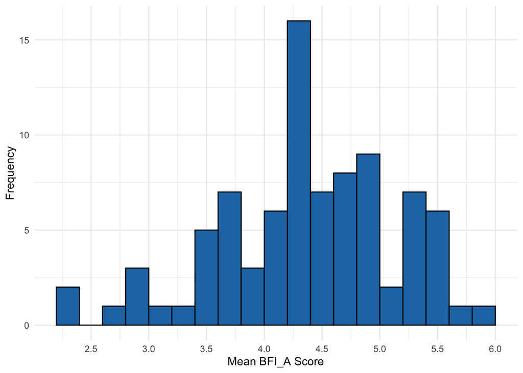

```r
fill_color_agree <- "#1f78b4"

ggplot(data_processed_after_exclusions, aes(x = mean_bfi_a)) +
  geom_histogram(binwidth = 0.2,
                 boundary = 1,
                 fill = fill_color_agree,
                 color = "black") +
  xlab("Mean BFI_A Score") +
  ylab("Frequency") +
  theme_minimal() +
  scale_x_continuous(breaks = pretty_breaks(n = 10))
```

*1.2 bfi_a1 - bfi_a9*

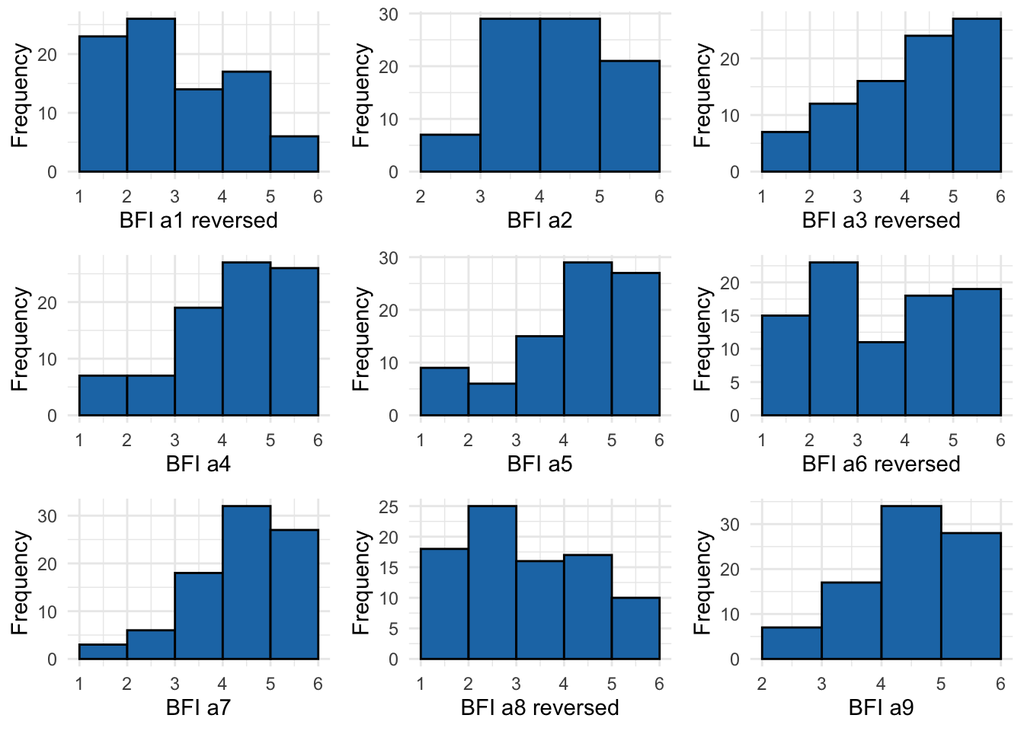

```r
fill_color_agree <- "#1f78b4"

#----

plot_a1 <- ggplot(data_processed_after_exclusions, aes(x = bfi_a1_reversed)) +
  geom_histogram(binwidth = 1,
                 boundary = 0,
                 fill = fill_color_agree,
                 color = "black") +
  xlab("BFI a1 reversed") +
  ylab("Frequency") +
  theme_minimal() +
  scale_x_continuous(breaks = pretty_breaks(n = 6))

plot_a2 <- ggplot(data_processed_after_exclusions, aes(x = bfi_a2)) +
  geom_histogram(binwidth = 1,
                 boundary = 0,
                 fill = fill_color_agree,
                 color = "black") +
  xlab("BFI a2") +
  ylab("Frequency") +
  theme_minimal() +
  scale_x_continuous(breaks = pretty_breaks(n = 6))

plot_a3 <- ggplot(data_processed_after_exclusions, aes(x = bfi_a3_reversed)) +
  geom_histogram(binwidth = 1,
                 boundary = 0,
                 fill = fill_color_agree,
                 color = "black") +
  xlab("BFI a3 reversed") +
  ylab("Frequency") +
  theme_minimal() +
  scale_x_continuous(breaks = pretty_breaks(n = 6))

plot_a4 <- ggplot(data_processed_after_exclusions, aes(x = bfi_a4)) +
  geom_histogram(binwidth = 1,
                 boundary = 0,
                 fill = fill_color_agree,
                 color = "black") +
  xlab("BFI a4") +
  ylab("Frequency") +
  theme_minimal() +
  scale_x_continuous(breaks = pretty_breaks(n = 6))

plot_a5 <- ggplot(data_processed_after_exclusions, aes(x = bfi_a5)) +
  geom_histogram(binwidth = 1,
                 boundary = 0,
                 fill = fill_color_agree,
                 color = "black") +
  xlab("BFI a5") +
  ylab("Frequency") +
  theme_minimal() +
  scale_x_continuous(breaks = pretty_breaks(n = 6))

plot_a6 <- ggplot(data_processed_after_exclusions, aes(x = bfi_a6_reversed)) +
  geom_histogram(binwidth = 1,
                 boundary = 0,
                 fill = fill_color_agree,
                 color = "black") +
  xlab("BFI a6 reversed") +
  ylab("Frequency") +
  theme_minimal() +
  scale_x_continuous(breaks = pretty_breaks(n = 6))

plot_a7 <- ggplot(data_processed_after_exclusions, aes(x = bfi_a7)) +
  geom_histogram(binwidth = 1,
                 boundary = 0,
                 fill = fill_color_agree,
                 color = "black") +
  xlab("BFI a7") +
  ylab("Frequency") +
  theme_minimal() +
  scale_x_continuous(breaks = pretty_breaks(n = 6))

plot_a8 <- ggplot(data_processed_after_exclusions, aes(x = bfi_a8_reversed)) +
  geom_histogram(binwidth = 1,
                 boundary = 0,
                 fill = fill_color_agree,
                 color = "black") +
  xlab("BFI a8 reversed") +
  ylab("Frequency") +
  theme_minimal() +
  scale_x_continuous(breaks = pretty_breaks(n = 6))

plot_a9 <- ggplot(data_processed_after_exclusions, aes(x = bfi_a9)) +
  geom_histogram(binwidth = 1,
                 boundary = 0,
                 fill = fill_color_agree,
                 color = "black") +
  xlab("BFI a9") +
  ylab("Frequency") +
  theme_minimal() +
  scale_x_continuous(breaks = pretty_breaks(n = 6))


plot_grid(plot_a1, plot_a2, plot_a3, plot_a4, plot_a5, plot_a6, plot_a7, plot_a8, plot_a9, labels = , nrow = 3)
```

## 2. Cosnscientiousness

*2.1 mean_bfi_c*

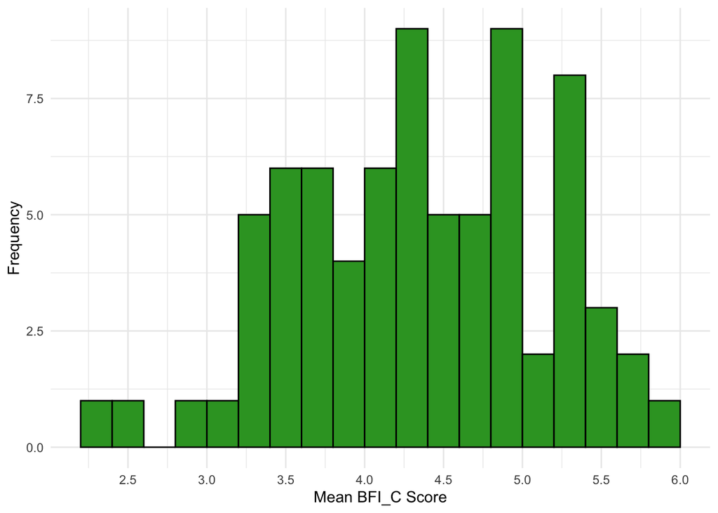

```r
fill_color_consc <- "#33a02c"

ggplot(data_processed_after_exclusions, aes(x = mean_bfi_c)) +
  geom_histogram(binwidth = 0.2,
                 boundary = 1,
                 fill = fill_color_consc,
                 color = "black") +
  xlab("Mean BFI_C Score") +
  ylab("Frequency") +
  theme_minimal() +
  scale_x_continuous(breaks = pretty_breaks(n = 10))
```

*2.2 bfi_c1 - bfi_c9*

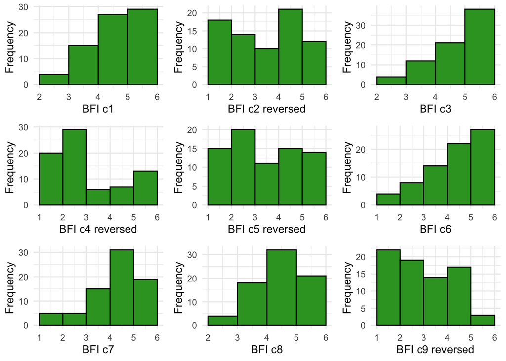

```r
fill_color_agree <- "#33a02c"

#----

plot_c1 <- ggplot(data_processed_after_exclusions, aes(x = bfi_c1)) +
  geom_histogram(binwidth = 1,
                 boundary = 0,
                 fill = fill_color_agree,
                 color = "black") +
  xlab("BFI c1") +
  ylab("Frequency") +
  theme_minimal() +
  scale_x_continuous(breaks = pretty_breaks(n = 6))

plot_c2 <- ggplot(data_processed_after_exclusions, aes(x = bfi_c2_reversed)) +
  geom_histogram(binwidth = 1,
                 boundary = 0,
                 fill = fill_color_agree,
                 color = "black") +
  xlab("BFI c2 reversed") +
  ylab("Frequency") +
  theme_minimal() +
  scale_x_continuous(breaks = pretty_breaks(n = 6))

plot_c3 <- ggplot(data_processed_after_exclusions, aes(x = bfi_c3)) +
  geom_histogram(binwidth = 1,
                 boundary = 0,
                 fill = fill_color_agree,
                 color = "black") +
  xlab("BFI c3") +
  ylab("Frequency") +
  theme_minimal() +
  scale_x_continuous(breaks = pretty_breaks(n = 6))

plot_c4 <- ggplot(data_processed_after_exclusions, aes(x = bfi_c4_reversed)) +
  geom_histogram(binwidth = 1,
                 boundary = 0,
                 fill = fill_color_agree,
                 color = "black") +
  xlab("BFI c4 reversed") +
  ylab("Frequency") +
  theme_minimal() +
  scale_x_continuous(breaks = pretty_breaks(n = 6))

plot_c5 <- ggplot(data_processed_after_exclusions, aes(x = bfi_c5_reversed)) +
  geom_histogram(binwidth = 1,
                 boundary = 0,
                 fill = fill_color_agree,
                 color = "black") +
  xlab("BFI c5 reversed") +
  ylab("Frequency") +
  theme_minimal() +
  scale_x_continuous(breaks = pretty_breaks(n = 6))

plot_c6 <- ggplot(data_processed_after_exclusions, aes(x = bfi_c6)) +
  geom_histogram(binwidth = 1,
                 boundary = 0,
                 fill = fill_color_agree,
                 color = "black") +
  xlab("BFI c6") +
  ylab("Frequency") +
  theme_minimal() +
  scale_x_continuous(breaks = pretty_breaks(n = 6))

plot_c7 <- ggplot(data_processed_after_exclusions, aes(x = bfi_c7)) +
  geom_histogram(binwidth = 1,
                 boundary = 0,
                 fill = fill_color_agree,
                 color = "black") +
  xlab("BFI c7") +
  ylab("Frequency") +
  theme_minimal() +
  scale_x_continuous(breaks = pretty_breaks(n = 6))

plot_c8 <- ggplot(data_processed_after_exclusions, aes(x = bfi_c8)) +
  geom_histogram(binwidth = 1,
                 boundary = 0,
                 fill = fill_color_agree,
                 color = "black") +
  xlab("BFI c8") +
  ylab("Frequency") +
  theme_minimal() +
  scale_x_continuous(breaks = pretty_breaks(n = 6))

plot_c9 <- ggplot(data_processed_after_exclusions, aes(x = bfi_c9_reversed)) +
  geom_histogram(binwidth = 1,
                 boundary = 0,
                 fill = fill_color_agree,
                 color = "black") +
  xlab("BFI c9 reversed") +
  ylab("Frequency") +
  theme_minimal() +
  scale_x_continuous(breaks = pretty_breaks(n = 6))

plot_grid(plot_c1, plot_c2, plot_c3, plot_c4, plot_c5, plot_c6, plot_c7, plot_c8, plot_c9, labels = , nrow = 3)
```

## 3. Extraverstion

*3.1 mean_bfi_e*

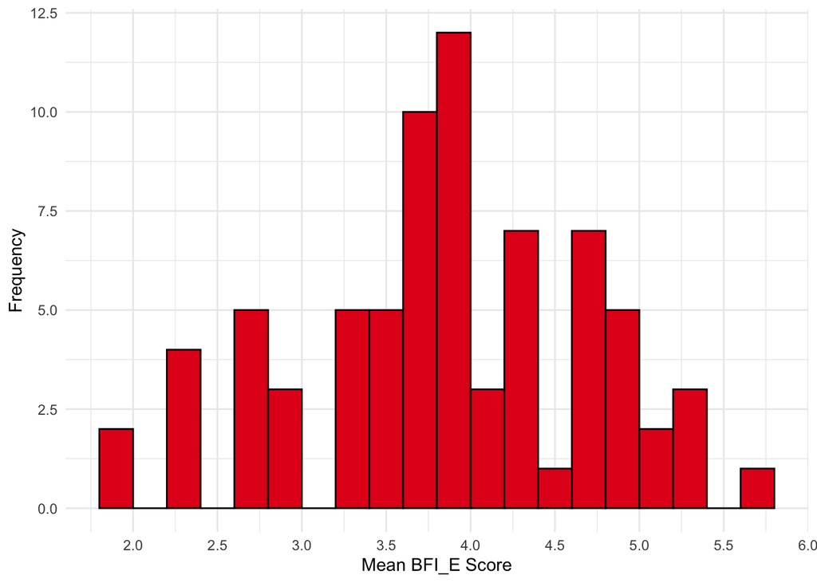

```r
fill_color_extra <- "#e31a1c"

ggplot(data_processed_after_exclusions, aes(x = mean_bfi_e)) +
  geom_histogram(binwidth = 0.2,
                 boundary = 1,
                 fill = fill_color_extra,
                 color = "black") +
  xlab("Mean BFI_E Score") +
  ylab("Frequency") +
  theme_minimal() +
  scale_x_continuous(breaks = pretty_breaks(n = 10))
```

*3.2 bfi_e1 - bfi_e8*

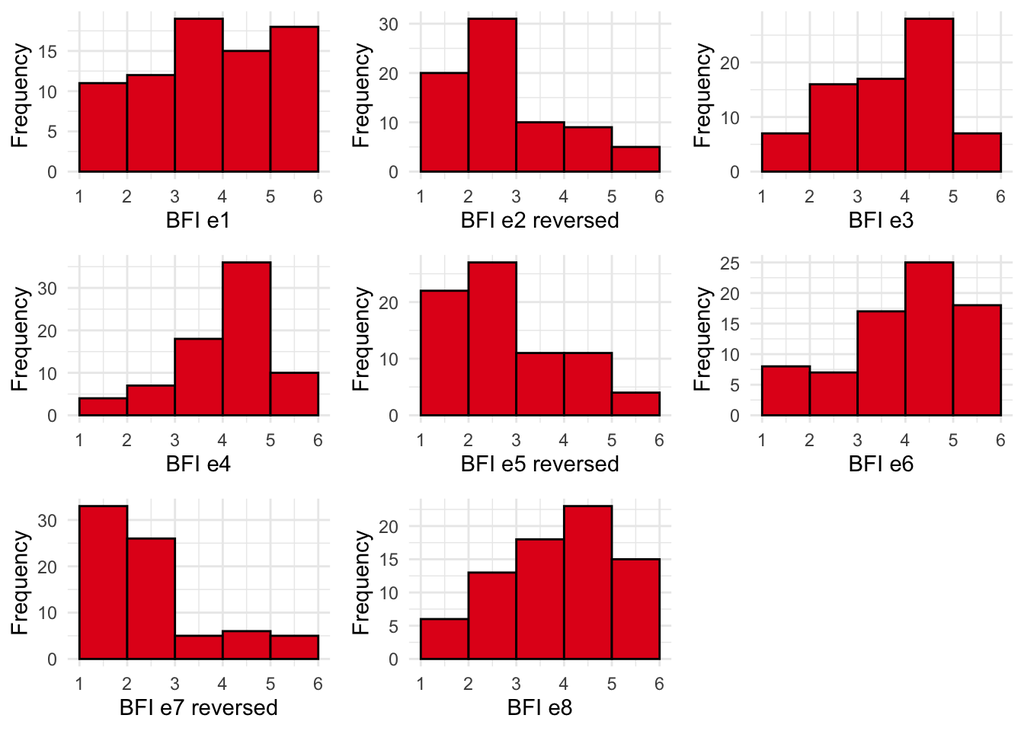

```r
fill_color_agree <- "#e31a1c"

#----

plot_e1 <- ggplot(data_processed_after_exclusions, aes(x = bfi_e1)) +
  geom_histogram(binwidth = 1,
                 boundary = 0,
                 fill = fill_color_agree,
                 color = "black") +
  xlab("BFI e1") +
  ylab("Frequency") +
  theme_minimal() +
  scale_x_continuous(breaks = pretty_breaks(n = 6))

plot_e2 <- ggplot(data_processed_after_exclusions, aes(x = bfi_e2_reversed)) +
  geom_histogram(binwidth = 1,
                 boundary = 0,
                 fill = fill_color_agree,
                 color = "black") +
  xlab("BFI e2 reversed") +
  ylab("Frequency") +
  theme_minimal() +
  scale_x_continuous(breaks = pretty_breaks(n = 6))

plot_e3 <- ggplot(data_processed_after_exclusions, aes(x = bfi_e3)) +
  geom_histogram(binwidth = 1,
                 boundary = 0,
                 fill = fill_color_agree,
                 color = "black") +
  xlab("BFI e3") +
  ylab("Frequency") +
  theme_minimal() +
  scale_x_continuous(breaks = pretty_breaks(n = 6))

plot_e4 <- ggplot(data_processed_after_exclusions, aes(x = bfi_e4)) +
  geom_histogram(binwidth = 1,
                 boundary = 0,
                 fill = fill_color_agree,
                 color = "black") +
  xlab("BFI e4") +
  ylab("Frequency") +
  theme_minimal() +
  scale_x_continuous(breaks = pretty_breaks(n = 6))

plot_e5 <- ggplot(data_processed_after_exclusions, aes(x = bfi_e5_reversed)) +
  geom_histogram(binwidth = 1,
                 boundary = 0,
                 fill = fill_color_agree,
                 color = "black") +
  xlab("BFI e5 reversed") +
  ylab("Frequency") +
  theme_minimal() +
  scale_x_continuous(breaks = pretty_breaks(n = 6))

plot_e6 <- ggplot(data_processed_after_exclusions, aes(x = bfi_e6)) +
  geom_histogram(binwidth = 1,
                 boundary = 0,
                 fill = fill_color_agree,
                 color = "black") +
  xlab("BFI e6") +
  ylab("Frequency") +
  theme_minimal() +
  scale_x_continuous(breaks = pretty_breaks(n = 6))

plot_e7 <- ggplot(data_processed_after_exclusions, aes(x = bfi_e7_reversed)) +
  geom_histogram(binwidth = 1,
                 boundary = 0,
                 fill = fill_color_agree,
                 color = "black") +
  xlab("BFI e7 reversed") +
  ylab("Frequency") +
  theme_minimal() +
  scale_x_continuous(breaks = pretty_breaks(n = 6))

plot_e8 <- ggplot(data_processed_after_exclusions, aes(x = bfi_e8)) +
  geom_histogram(binwidth = 1,
                 boundary = 0,
                 fill = fill_color_agree,
                 color = "black") +
  xlab("BFI e8") +
  ylab("Frequency") +
  theme_minimal() +
  scale_x_continuous(breaks = pretty_breaks(n = 6))


plot_grid(plot_e1, plot_e2, plot_e3, plot_e4, plot_e5, plot_e6, plot_e7, plot_e8, labels = , nrow = 3)
```

## 4. Neuroticism

*4.1 mean_bfi_n*

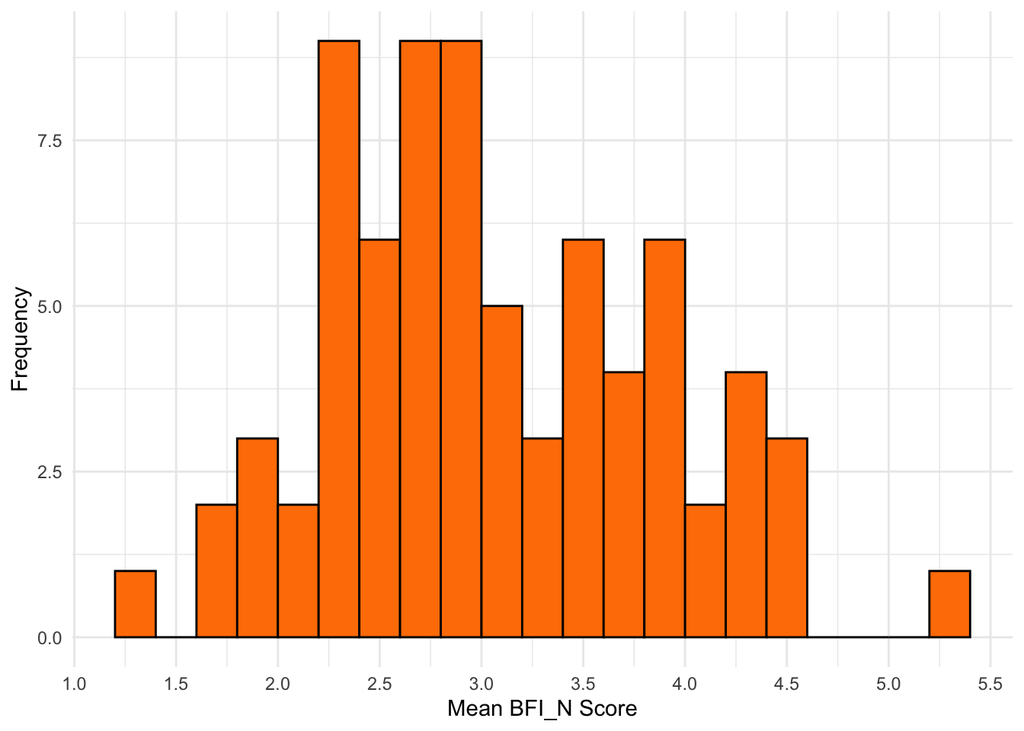

```r
fill_color_neuro <- "#ff7f00"

ggplot(data_processed_after_exclusions, aes(x = mean_bfi_n)) +
  geom_histogram(binwidth = 0.2,
                 boundary = 1,
                 fill = fill_color_neuro,
                 color = "black") +
  xlab("Mean BFI_N Score") +
  ylab("Frequency") +
  theme_minimal() +
  scale_x_continuous(breaks = pretty_breaks(n = 10))
```

*4.2 bfi_n1 - bfi_n8*

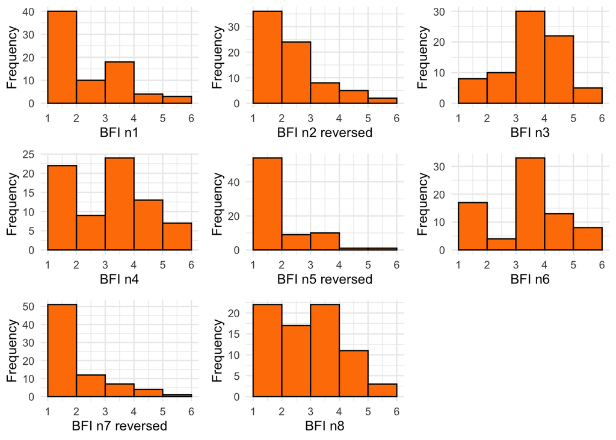

```r
fill_color_agree <- "#ff7f00"

#----
plot_n1 <- ggplot(data_processed_after_exclusions, aes(x = bfi_n1)) +
  geom_histogram(binwidth = 1,
                 boundary = 0,
                 fill = fill_color_agree,
                 color = "black") +
  xlab("BFI n1") +
  ylab("Frequency") +
  theme_minimal() +
  scale_x_continuous(breaks = pretty_breaks(n = 6))

plot_n2 <- ggplot(data_processed_after_exclusions, aes(x = bfi_n2_reversed)) +
  geom_histogram(binwidth = 1,
                 boundary = 0,
                 fill = fill_color_agree,
                 color = "black") +
  xlab("BFI n2 reversed") +
  ylab("Frequency") +
  theme_minimal() +
  scale_x_continuous(breaks = pretty_breaks(n = 6))

plot_n3 <- ggplot(data_processed_after_exclusions, aes(x = bfi_n3)) +
  geom_histogram(binwidth = 1,
                 boundary = 0,
                 fill = fill_color_agree,
                 color = "black") +
  xlab("BFI n3") +
  ylab("Frequency") +
  theme_minimal() +
  scale_x_continuous(breaks = pretty_breaks(n = 6))

plot_n4 <- ggplot(data_processed_after_exclusions, aes(x = bfi_n4)) +
  geom_histogram(binwidth = 1,
                 boundary = 0,
                 fill = fill_color_agree,
                 color = "black") +
  xlab("BFI n4") +
  ylab("Frequency") +
  theme_minimal() +
  scale_x_continuous(breaks = pretty_breaks(n = 6))

plot_n5 <- ggplot(data_processed_after_exclusions, aes(x = bfi_n5_reversed)) +
  geom_histogram(binwidth = 1,
                 boundary = 0,
                 fill = fill_color_agree,
                 color = "black") +
  xlab("BFI n5 reversed") +
  ylab("Frequency") +
  theme_minimal() +
  scale_x_continuous(breaks = pretty_breaks(n = 6))

plot_n6 <- ggplot(data_processed_after_exclusions, aes(x = bfi_n6)) +
  geom_histogram(binwidth = 1,
                 boundary = 0,
                 fill = fill_color_agree,
                 color = "black") +
  xlab("BFI n6") +
  ylab("Frequency") +
  theme_minimal() +
  scale_x_continuous(breaks = pretty_breaks(n = 6))

plot_n7 <- ggplot(data_processed_after_exclusions, aes(x = bfi_n7_reversed)) +
  geom_histogram(binwidth = 1,
                 boundary = 0,
                 fill = fill_color_agree,
                 color = "black") +
  xlab("BFI n7 reversed") +
  ylab("Frequency") +
  theme_minimal() +
  scale_x_continuous(breaks = pretty_breaks(n = 6))

plot_n8 <- ggplot(data_processed_after_exclusions, aes(x = bfi_n8)) +
  geom_histogram(binwidth = 1,
                 boundary = 0,
                 fill = fill_color_agree,
                 color = "black") +
  xlab("BFI n8") +
  ylab("Frequency") +
  theme_minimal() +
  scale_x_continuous(breaks = pretty_breaks(n = 6))

plot_grid(plot_n1, plot_n2, plot_n3, plot_n4, plot_n5, plot_n6, plot_n7, plot_n8, labels = , nrow = 3)
```